# Tooth Growth Analysis

Wiktoria Urantowka

8/20/2017

The goal of this report id to analyze the ToothGrowth data in R in order to investigate the impact of vitamine C on the tooth growth in ginea pigs.

### 1.Loading the data and basic exploratory analysis

```r
library(ggplot2)
data(ToothGrowth)
head(ToothGrowth)
```

```
##    len supp dose
## 1  4.2   VC  0.5
## 2 11.5   VC  0.5
## 3  7.3   VC  0.5
## 4  5.8   VC  0.5
## 5  6.4   VC  0.5
## 6 10.0   VC  0.5
```

```r
dim(ToothGrowth)
```

```
## [1] 60  3
```

```r
str(ToothGrowth)
```

```
## 'data.frame':    60 obs. of  3 variables:
##  $ len : num  4.2 11.5 7.3 5.8 6.4 10 11.2 11.2 5.2 7 ...
##  $ supp: Factor w/ 2 levels "OJ","VC": 2 2 2 2 2 2 2 2 2 2 ...
##  $ dose: num  0.5 0.5 0.5 0.5 0.5 0.5 0.5 0.5 0.5 0.5 ...
```

The data consists of 60 observations for 3 variables: Tooth length (numeric), supplement type, VC or OJ (factor) and the dosage in milligrams of this supplement (numeric)

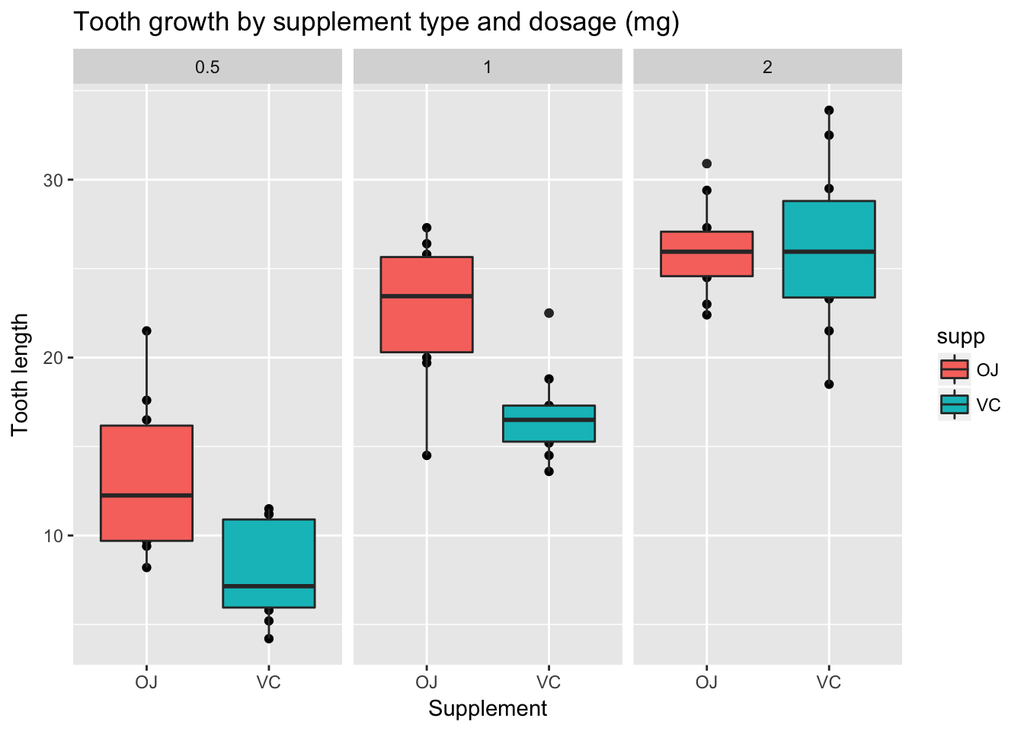

```r
qplot(supp,len,data=ToothGrowth, facets=~dose, main="Tooth growth by supplement type and dosage (mg)",xlab="Supplement", ylab="Tooth length") + geom_boxplot(aes(fill = supp))
```

One can observe a positive correlation between the dosage and the tooth growth. For lower dosage, the affect of VC seams weaker than OJ, but this difference dissapears with the highest dosage.

### 2.Hypothesis Testing:

#### 1 Difference of effect between supplements

Ho = no difference in tooth growth when using the supplement OJ and VC (lenOJ == lenVC) Ha = Tooth grow more when using supplement OJ instead of VC. (lenOJ>lenVC)

Assumptions -Variances of tooth growth are different for different supplements and their dosage. -Tooth growth follows normal distribution. -variables are i.i.d.

Procedure: - tooth growth by supplement type from the data

```r
OJ = ToothGrowth$len[ToothGrowth$supp == 'OJ']
VC = ToothGrowth$len[ToothGrowth$supp == 'VC']
```

-One-tailed independent t-test with unequal variance.

```r
t.test(OJ, VC, alternative = "greater", paired = FALSE, var.equal = FALSE, conf.level = 0.95)
```

```
##
##  Welch Two Sample t-test
##
## data:  OJ and VC
## t = 1.9153, df = 55.309, p-value = 0.03032
## alternative hypothesis: true difference in means is greater than 0
## 95 percent confidence interval:
##  0.4682687       Inf
## sample estimates:
## mean of x mean of y
##  20.66333  16.96333
```

As the p-value < 0.05 the null hypothesis is rejected. –> Supplement OJ has bigger effect on tooth growth than supplement VC

#### 2 Difference of effects among dosages

2.1(Comparaison between affect of dosage 0.5 and 1) Ho= no difference in tooth growth between dosages. Ha= more tooth growth when the dosage increases.

Procedure: -tooth growth by dosage.

```r
doseHalf = ToothGrowth$len[ToothGrowth$dose == 0.5]
doseOne = ToothGrowth$len[ToothGrowth$dose == 1]
doseTwo = ToothGrowth$len[ToothGrowth$dose == 2]
```

-One-tailed independent t-test with unequal variance.

```r
t.test(doseHalf, doseOne, alternative = "less", paired = FALSE, var.equal = FALSE, conf.level = 0.95)
```

```
##
##  Welch Two Sample t-test
##
## data:  doseHalf and doseOne
## t = -6.4766, df = 37.986, p-value = 6.342e-08
## alternative hypothesis: true difference in means is less than 0
## 95 percent confidence interval:
##       -Inf -6.753323
## sample estimates:
## mean of x mean of y
##    10.605    19.735
```

As the p-value < 0.05 the null hypothesis is rejected. (There is a difference in effects on tooth growth for dosages 0.5 and 1, dosage 1 having bigger effect)

2.2(Comparaison between affect of dosage 1 and 2)

```r
t.test(doseOne, doseTwo, alternative = "less", paired = FALSE, var.equal = FALSE, conf.level = 0.95)
```

```
##
##  Welch Two Sample t-test
##
## data:  doseOne and doseTwo
## t = -4.9005, df = 37.101, p-value = 9.532e-06
## alternative hypothesis: true difference in means is less than 0
## 95 percent confidence interval:
##      -Inf -4.17387
## sample estimates:
## mean of x mean of y
##    19.735    26.100
```

As the p-value < 0.05 the null hypothesis is rejected. (There is a difference in effects on tooth growth for dosages 1 and 2, dosage 2 having bigger effect)

–> Dosage matters: The more supplement, the more tooth growth